# Analsis of 2019 Creel Survey Data

V. Starnes

16 July, 2019

# Objective

A roving creel survey was competed from March 1st-May 31st 2019, and a modified bus route creel survey was completed from June 1st-July 1st 2019. Data from these surveys can be used to estimate the average effort, CPUE, and harvest of anglers. Additional estimates of refuge usage patterns can be made from vehicle counts and observations taken during the bus route design.

**March (Roving)** Angler hours - 335.64 CPUE - 1.12 Esimated Harvest for March - 376

# Fish Targeted By Anglers

During interviews anglers were asked what kind of fish they were hoping to catch. The following graphs illustrate the frequency each generalized group of fish that were reported. The first graph shows that anglers mostly targeted bream and crappie. However, the second graph, which is separated by month, shows that crappie fishing declined in late spring as fishing for bream increases going into the summer. This graph also shows a decrease in bass fishing from spring to summer. Anglers often target species like crappie and bass in the spring during spawning. The shift from more desirable game species to bream could be a response to the decreased catchability of crappie and bass.

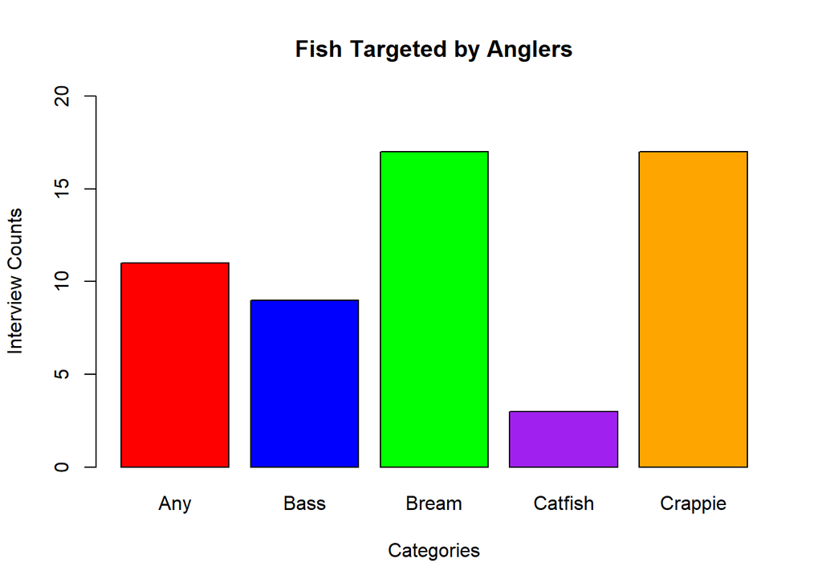

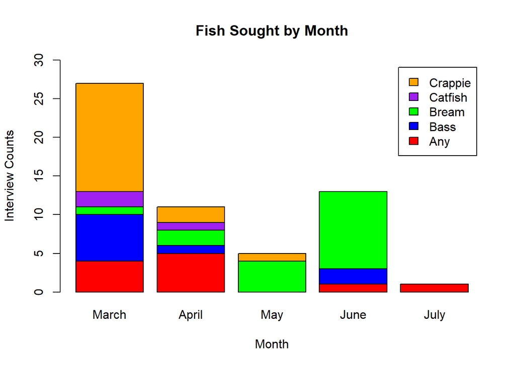

# Species Caught By Anglers

During interviews the type of fish caught by anglers was recorded. The following graphs illustrate the frequency each generalized group of fish that were reported. The first graph clearly shows that bream was the most commonly reported category, followed by crappie and bass. The second graph shows a decline in the number of interviews where crappie and bass were reported from the spring to the summer. However, the number of interviews where anglers reported successfully harvesting bream remains constant with a sharp increase in June. This could be a result of the increase in the number of anglers targeting bream specifically.

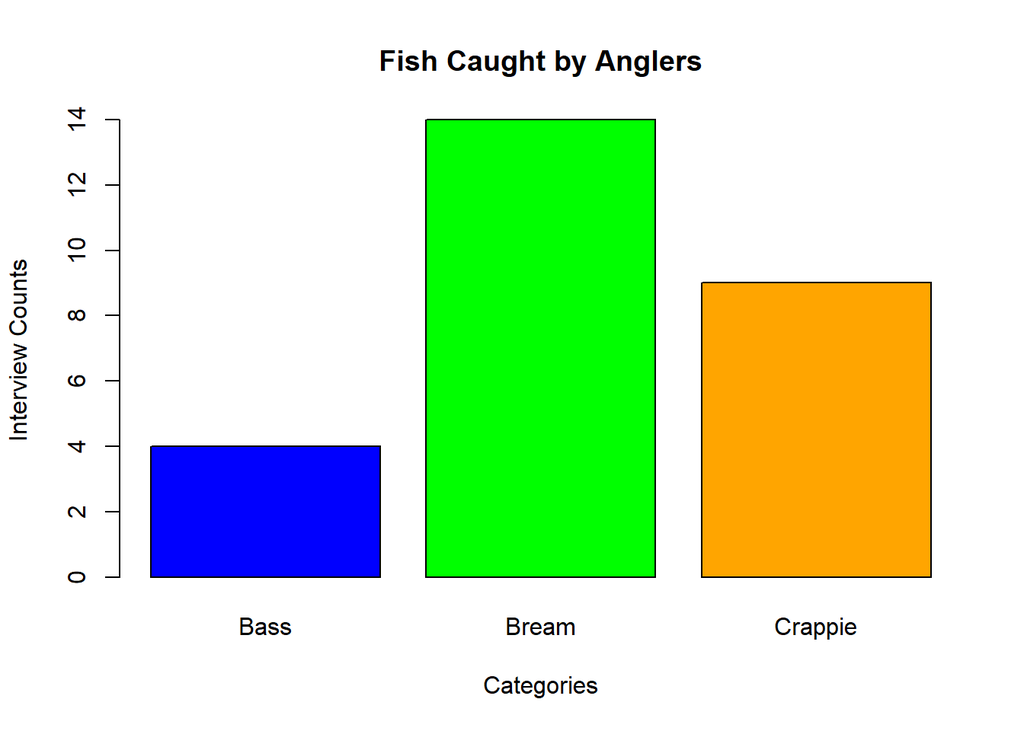

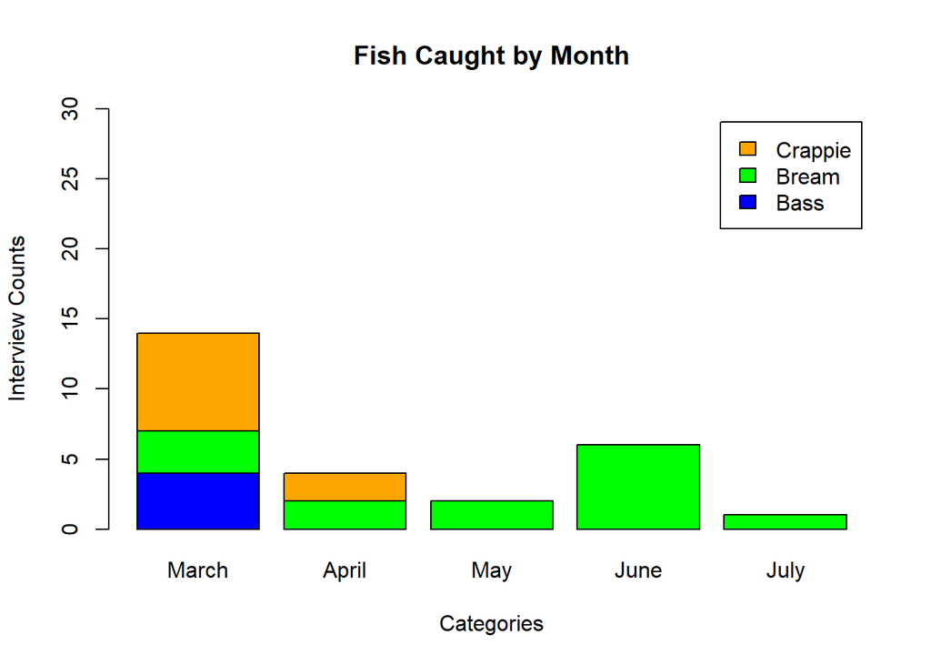

# Time Fished

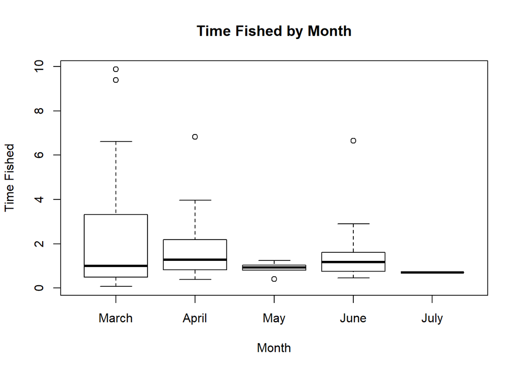

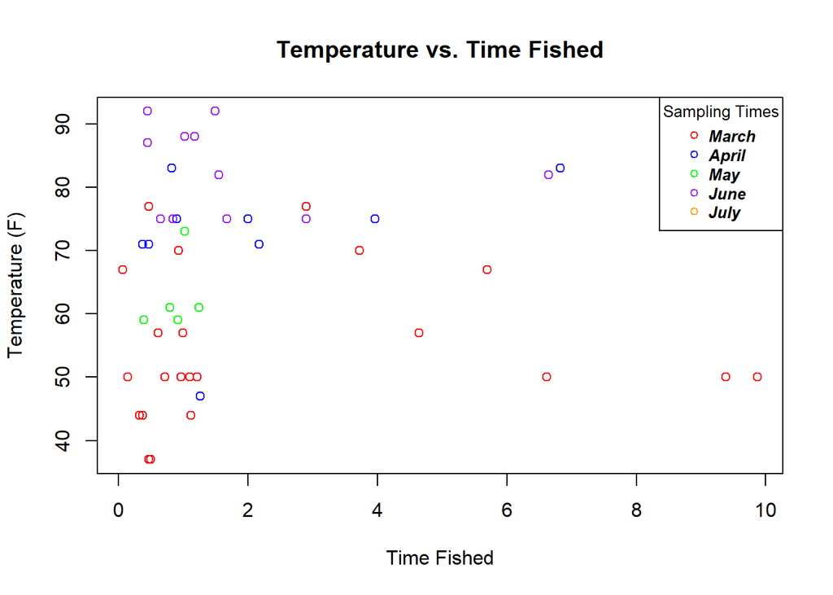

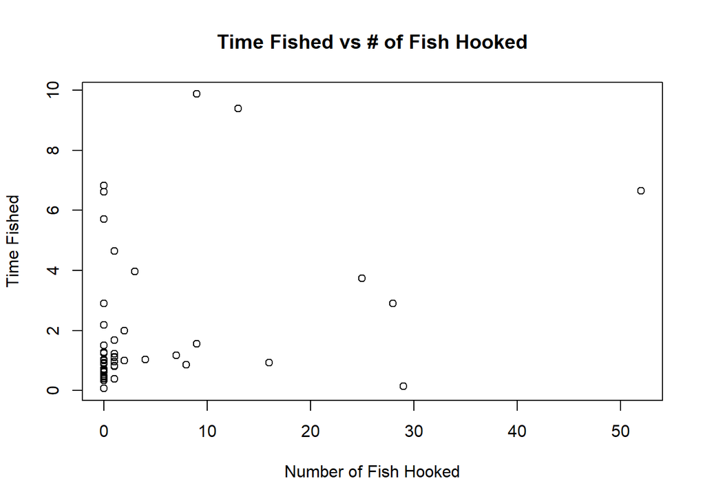

# Environmental Covariates

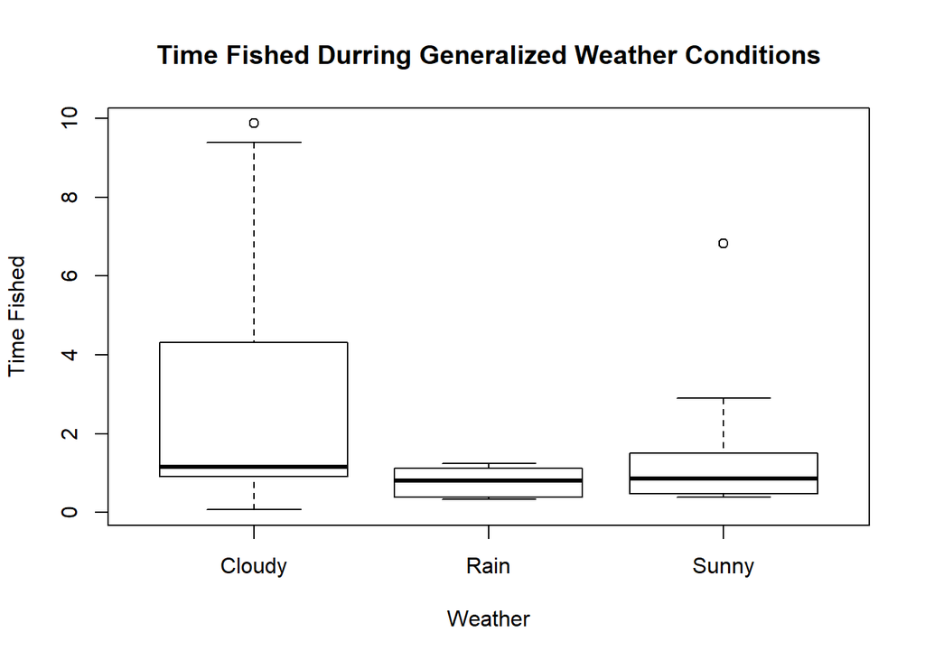

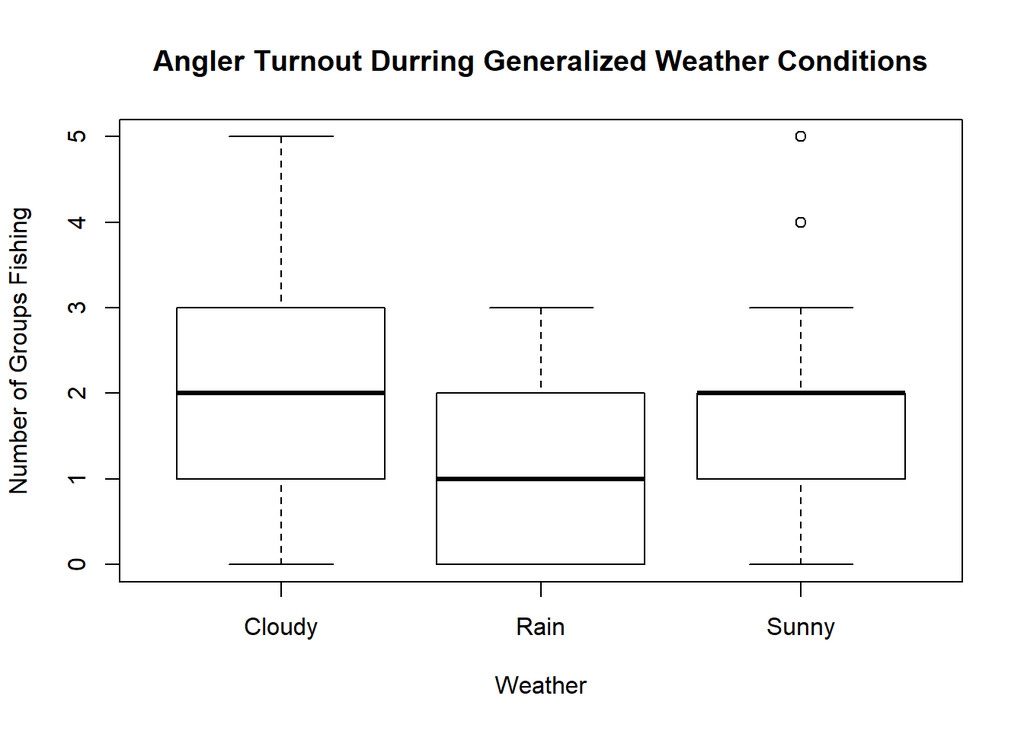

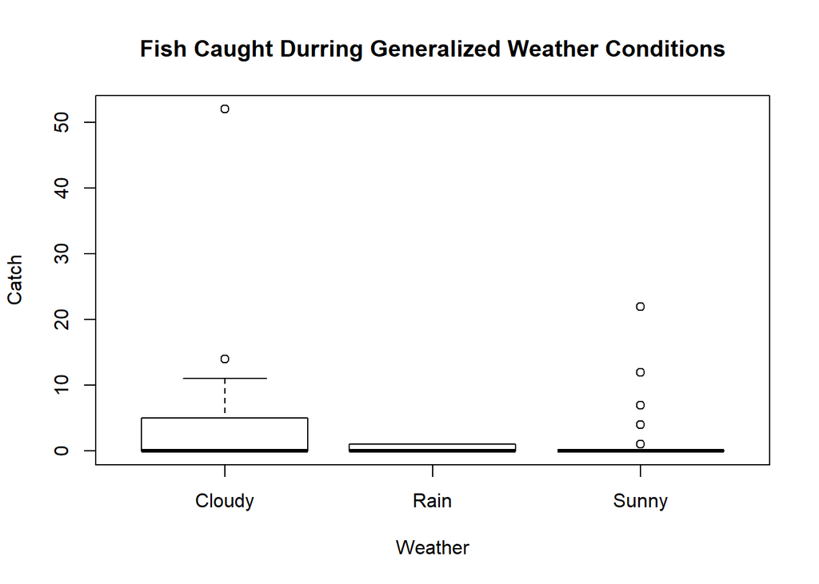

# Angler Origin

During interviews anglers reported their resident county. All counties reported by angers connect to Oktibbeha County. The three most frequently reported counties are Oktibbeha, Noxubee, and Winston counties which are the same three counties covered by the Sam D. Hamilton Noxubee National Wildlife Refuge. The population size of each county and their proximity to Buff Lake could be responsible for higher angler turnouts from these counties.

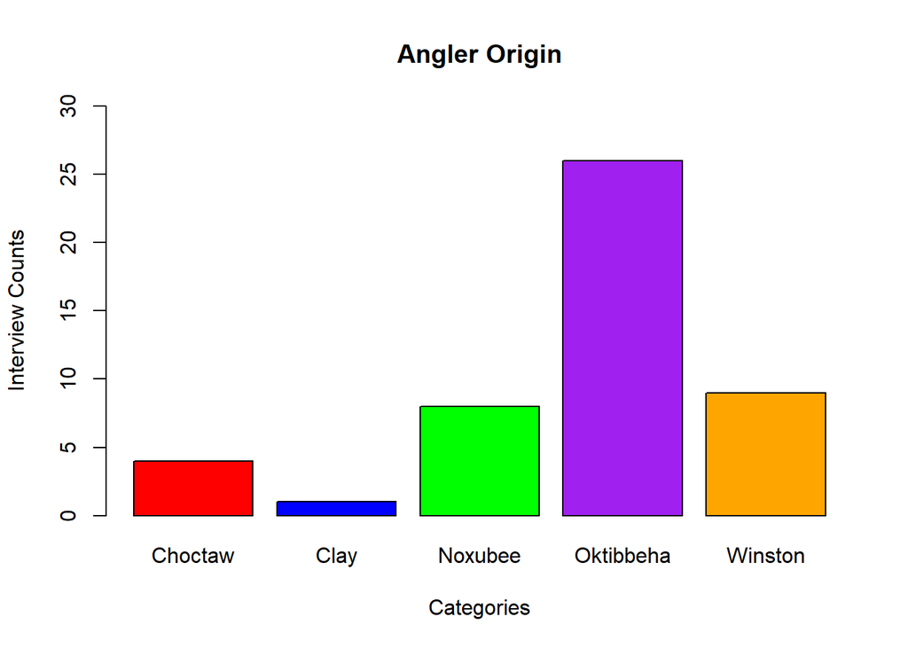

# Activities on the Refuge

During the bus route creel survey creel clerks waited at three different sites within the refuge for two hours each. At each site the clerk recorded the arrival and departure time of vehicles. The clerk also recorded any activities that the individuals from each vehicle participated in. If no activity was observed, it was marked as “other”. The most frequently recorded activities were walking, bank fishing, and boat fishing. Excluding the “other” category, boat fishing had the longest wait times on average. Although the “walking” category was the most frequent reported, it had the shortest wait times at each access point, averaging around 15 minutes.

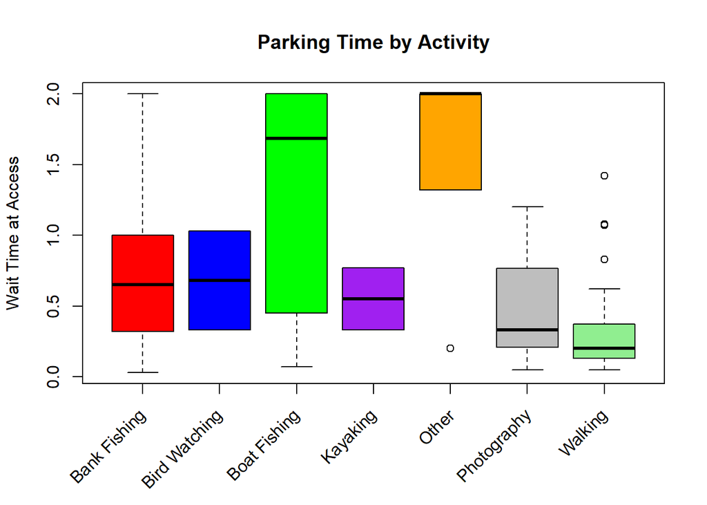

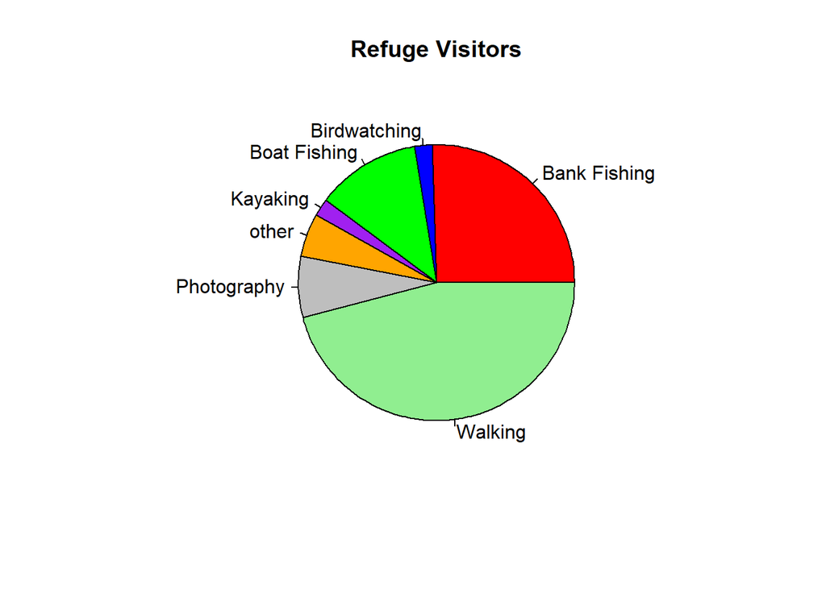